# Robert_Ścieszka_Projekt

The aim of this project was to extend the implementation of the diffusion equation in 1-dimension.

The outcome of this extension is effectively - the three implemented equations in not one, but two dimensions:

- diffusion equation,
- non-linear convection equation,
- Burgers' equation (which is the combination of the previous two).

What is more, the code is supposed to be optimized properly, which was obtained (up to some point) after some improvements. For sure is can be done better, although the code is already pretty fast, which is seen as success.

The diffusion equation

The very first equation is the diffusion equation, the implementation is pretty standard.

Derivatives, of which the equation is built - are being discretized in space and time with Difference Scheme, so that the equation can be solved to obtain the solution advancing in time.

Initial u is set to be a hat function in a given place in space. The loop is very simple, but the difference in formulating it is really negligible. What isn't negligible, is the fact, that the whole equation is written in one line of the loop, which gives the results faster. This is the main source of improvement.

Everything is wrapped in a function - returning the coordinates, time and the values of u. "numba" library is also used, which speeds up the code.

```python
%%time
import numba as nb
import numpy as np
import matplotlib.pyplot as plt
from matplotlib import cm
from mpl_toolkits.mplot3d import Axes3D
@nb.njit(fastmath=True)          # numba is used to speed up the calculations!
def diff(u,x,y, step):
    dx = L/(N-1)                 # x distance between two adjacent points, the spacial-step (also x[1] - x[0] can be used here)
    dy = K/(M-1)
    nu = 0.1                     # diffusion coefficient
    sigma = 0.2                  # scaling factor for the below condition
    dt = sigma * dx*dy/nu        # Courant condition ensuring stability
    t = np.zeros(step)           # placeholder array for time

                                 # hat function of value = 2, as the initial condition for u and v inside: (4<=x<=6 and 4<=y<=6)
    u[int(4 / dy):int(6 / dy + 1),int(4 / dx):int(6 / dx + 1)] = 2

    for i in range(step):        # loop across the number of time steps
        un = u.copy()            # placeholder array for u which will be re-written for every loop and stored here
#         t[i] = i*dt*step      # can be uncommented to plot the time or something

        u[1:-1, 1:-1] = un[1:-1, 1:-1] + nu*dt/dx**2* \
        (un[1:-1, 2:] + un[1:-1, 0:-2] - 2*un[1:-1, 1:-1]) \
        + nu*dt/dy**2*(un[2:, 1:-1] + un[0:-2, 1:-1] - 2*un[1:-1, 1:-1]) # discretization

        u[0,:] = 1               # boundary conditions
        u[-1,:] = 1
        u[:,0] = 1
        u[:,-1] = 1
    return t, x, y, u
```

```
Wall time: 998 µs
```

After building our function, we declare needed variables and compile for 0 steps. So, just compile, not calculate.

```python
# variable declaration and the first compilation for step = 0

L, N = 10, 100          # length of our space and the number of grid points
K, M = 10, 100          # likewise
x = np.linspace(-L,L,N)
y = np.linspace(-K,K,M)
X, Y = np.meshgrid(x,y)

u = np.ones((N,M))      # creation of an array of ones, here will be stored "u" for a given timestep
un = np.ones((N,M))

diff(u,x,y, step=0);    # fast compilation
```

After that, we redeclare the variables and calculate everything, plotting the results.

```
Wall time: 167 ms
```

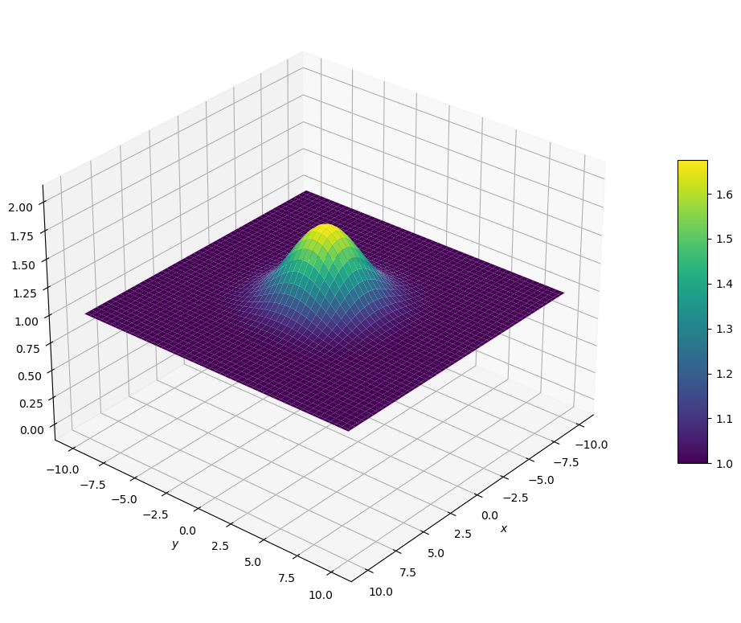

```python
%%time
L, N = 10, 100              # has to be defined here again, as the repetitive compilation of this very cell \
K, M = 10, 100              # would result in the overlaping results on the graph
x = np.linspace(-L,L,N)
y = np.linspace(-K,K,M)
X, Y = np.meshgrid(x,y)

u = np.ones((N,M))
un = np.ones((N,M))
t, x, y, u = diff(u, x, y, step = 150)

fig = plt.figure(figsize=(18, 10), dpi=100)
ax = fig.gca(projection='3d')
X, Y = np.meshgrid(x, y)
surf = ax.plot_surface(X, Y, u, rstride=2, cstride=2,
                       cmap=cm.viridis
#                            cmap=cm.coolwarm (different colours if you don't like these)
                       , linewidth=0, antialiased=True)
ax.view_init(elev=30, azim=40)
ax.set_xlabel('$x$');
ax.set_ylabel('$y$');
ax.set_zlim(-0.1, 2.1)
fig.colorbar(surf, shrink=0.5, aspect=10);
```

The above graph should present a stationary function, which magnitude is going down, as the solution advances in time.

Non-linear convection

This code is pretty much similar, but there are two equations. So some things are doubled here. The very "wave" should be not longer stationary, but it would be moving in a given direction. Note that there is no diffusion coefficient here.

```python
import numba as nb
import numpy as np
import matplotlib.pyplot as plt
from matplotlib import cm
from mpl_toolkits.mplot3d import Axes3D
@nb.njit(fastmath=True)          # numba is used to speed up the calculations!
def noncon(u,v,x,y, step):
    dx = L/(N-1)                 # x distance between two adjacent points, the spacial-step (also x[1] - x[0] can be used here)
    dy = K/(M-1)                 # the same for y
    sigma = 0.1                  # scale factor for the below condition
    dt = sigma * dx              # Courant condition ensuring stability
    t = np.zeros(step)           # placeholder array for time

                                 # hat function of value = 2, as the initial condition for u and v inside: (4<=x<=6 and 4<=y<=6)
    u[int(4 / dy):int(6 / dy + 1), int(4 / dx):int(6 / dx + 1)] = 2
    v[int(4 / dy):int(6 / dy + 1), int(4 / dx):int(6 / dx + 1)] = 2

    for i in range(step):        # loop across the number of time steps
        un = u.copy()            # placeholder arrays for u and v, which will be re-written for every loop and stored here
        vn = v.copy()
#         t[i] = i*dt*step      # can be uncommented to plot the time or something

        u[1:, 1:] = (un[1:, 1:] - \
        un[1:, 1:]*dt/dx*(un[1:, 1:] - un[1:, :-1]) - \
        vn[1:, 1:]*dt/dy*(un[1:, 1:] - un[:-1, 1:])) # discretization

        v[1:, 1:] = (vn[1:, 1:] - \
        un[1:, 1:]* dt/dx*(vn[1:, 1:] - vn[1:, :-1]) - \
        vn[1:, 1:]*dt/dy*(vn[1:, 1:] - vn[:-1, 1:])) # discretization

        u[0,:] = 1                # boundary conditions
        u[-1,:] = 1
        u[:,0] = 1
        u[:,-1] = 1

        v[0,:] = 1                # boundary conditions
        v[-1,:] = 1
        v[:,0] = 1
        v[:,-1] = 1
    return t, x, y, u, v
```

```python
# variable declaration and the first compilation for step = 0

L, N = 10, 81            # length of our space and the number of grid points
K, M = 10, 81            # likewise
x = np.linspace(-L,L,N)
y = np.linspace(-K,K,M)
X, Y = np.meshgrid(x,y)

u = np.ones((N,M))       # creation of an array of ones
un = np.ones((N,M))
v = np.ones((N,M))
vn = np.ones((N,M))

noncon(u,v,x,y, step=0); # fast compilation
```

```
Wall time: 79.9 ms
```

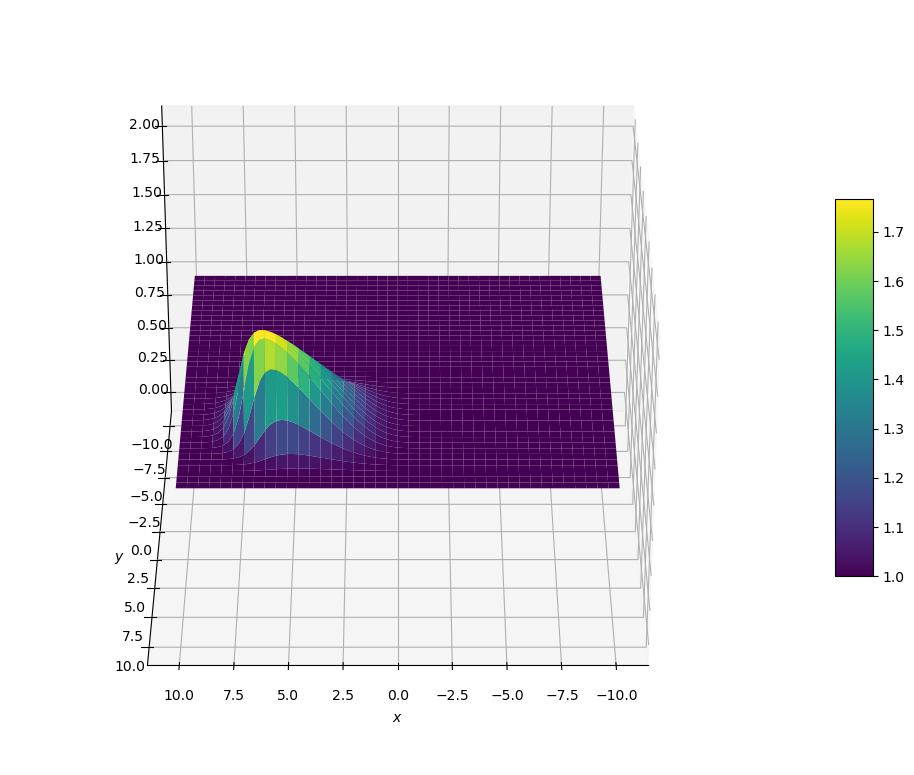

```python
%%time
L, N = 10, 81            # has to be defined here again, as the repetitive compilation of this very cell \
K, M = 10, 81            # would result in the overlaping results on the graph
x = np.linspace(-L,L,N)
y = np.linspace(-K,K,M)
X, Y = np.meshgrid(x,y)

u = np.ones((N,M))
un = np.ones((N,M))
v = np.ones((N,M))
vn = np.ones((N,M))
t, x, y, u, v = noncon(u, v, x, y, step = 150)


fig = plt.figure(figsize=(18, 10), dpi=100)
ax = fig.gca(projection='3d')
X, Y = np.meshgrid(x, y)
surf = ax.plot_surface(X, Y, u, rstride=2, cstride=2,
                       cmap=cm.viridis
#                            cmap=cm.coolwarm
                       , linewidth=0, antialiased=True)
ax.view_init(elev=30, azim=90)
ax.set_xlabel('$x$');
ax.set_ylabel('$y$');
ax.set_zlim(-0.1, 2.1)
fig.colorbar(surf, shrink=0.5, aspect=10);
```

The traveling wave is expected here, it also should reduce its size slightly. The very shape tends to be flattish in the front of the wave.

Burgers' equation

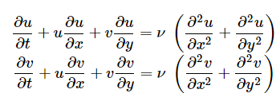

Burgers' equation is the combination of the previos two equations, so the "wave" should move and also be sort-of-sensitive to the diffusion coefficient value, which is actually called the viscosity in this equation.

```python
%%time
import numba as nb
import numpy as np
import matplotlib.pyplot as plt
from matplotlib import cm
from mpl_toolkits.mplot3d import Axes3D
@nb.njit(fastmath=True)         # numba is used to speed up the calculations!
def burgers(u,v,x,y, step):
    dx = L/(N-1)                # x distance between two adjacent points, the spacial-step (also x[1] - x[0] can be used here)
    dy = K/(M-1)                # the same for y
    nu = 0.009                 # diffusion coefficient (i.e. viscosity) -> 0.009 - 0.1 is very educational; 0.0035 - shock!
    sigma = 0.01                # scale factor for the below condition
    dt = sigma * dx*dy/nu       # Courant condition ensuring stability
    t = np.zeros(step)          # placeholder array for time

                                # hat function of value = 2, as the initial condition for u and v inside: (4<=x<=6 and 4<=y<=6)
    u[int(4 / dy):int(6 / dy + 1),int(4 / dx):int(6 / dx + 1)] = 2
    v[int(4 / dy):int(6 / dy + 1),int(4 / dx):int(6 / dx + 1)] = 2

    for i in range(step):       # loop across the number of time steps
        un = u.copy()           # placeholder arrays for u and v, which will be re-written for every loop and stored here
        vn = v.copy()
#         t[i] = i*dt*step       # can be uncommented to plot the time or something

        u[1:-1, 1:-1] = un[1:-1, 1:-1] + \
        nu*dt/dx**2*(un[1:-1, 2:] + un[1:-1, 0:-2] - 2*un[1:-1, 1:-1]) + \
        nu*dt/dy**2*(un[2:, 1:-1] + un[0:-2, 1:-1] - 2*un[1:-1, 1:-1]) - \
        dt/dx*un[1:-1, 1:-1]*(un[1:-1, 1:-1] - un[1:-1, 0:-2]) - \
        dt/dy*vn[1:-1, 1:-1]*(un[1:-1, 1:-1] - un[0:-2, 1:-1])               # discretization

        v[1:-1, 1:-1] = vn[1:-1, 1:-1] + \
        nu*dt/dx**2*(vn[1:-1, 2:] + vn[1:-1, 0:-2] - 2*vn[1:-1, 1:-1]) + \
        nu*dt/dy**2*(vn[2:, 1:-1] + vn[0:-2, 1:-1] - 2*vn[1:-1, 1:-1]) - \
        dt/dx*un[1:-1, 1:-1]*(vn[1:-1, 1:-1] - vn[1:-1, 0:-2]) - \
        dt/dy*vn[1:-1, 1:-1]*(vn[1:-1, 1:-1] - vn[0:-2, 1:-1])               # discretization


        u[0,:] = 1  # boundary conditions
        u[-1,:] = 1
        u[:,0] = 1
        u[:,-1] = 1

        v[0,:] = 1  # boundary conditions
        v[-1,:] = 1
        v[:,0] = 1
        v[:,-1] = 1
    return t, x, y, u, v
```

```
Wall time: 0 ns
```

```python
# variable declaration and the first compilation for step = 0

L, N = 10, 100              # length of our space and the number of grid points
K, M = 10, 100              # likewise
x = np.linspace(-L,L,N)
y = np.linspace(-K,K,M)
X, Y = np.meshgrid(x,y)

u = np.ones((N,M))          # creation of array of ones
un = np.ones((N,M))
v = np.ones((N,M))
vn = np.ones((N,M))

burgers(u,v,x,y, step = 0); # fast compilation
```

```
Wall time: 271 ms
```

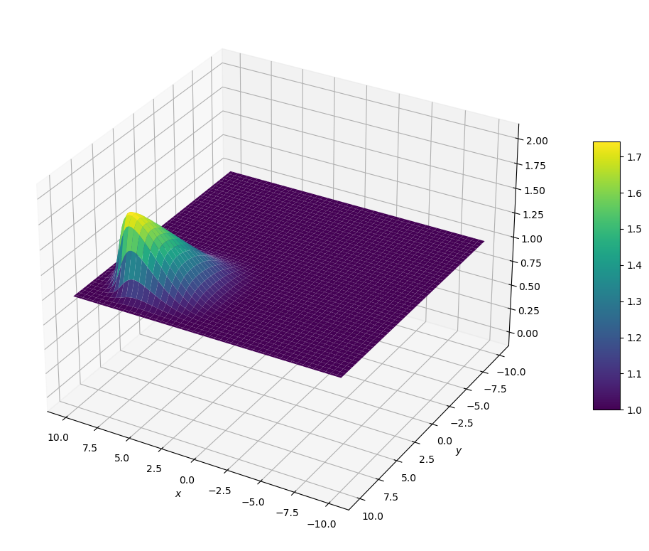

```python
%%time

L, N = 10, 100              # has to be defined here again, as the repetitive compilation of this very cell \
K, M = 10, 100              # would result in the overlaping results on the graph
x = np.linspace(-L,L,N)
y = np.linspace(-K,K,M)
X, Y = np.meshgrid(x,y)

u = np.ones((N,M))
un = np.ones((N,M))
v = np.ones((N,M))
vn = np.ones((N,M))

t, x, y, u, v = burgers(u, v, x, y, step = 200) # for nu = 0.0035, use 30+ steps to see a shock!


fig = plt.figure(figsize=(18, 10), dpi=100)
ax = fig.gca(projection='3d')
X, Y = np.meshgrid(x, y)
surf = ax.plot_surface(X, Y, u, rstride=2, cstride=2,
                       cmap=cm.viridis
#                            cmap=cm.coolwarm
                       , linewidth=0, antialiased=True)

ax.view_init(elev=30, azim=120)
ax.set_xlabel('$x$');
ax.set_ylabel('$y$');
ax.set_zlim(-0.1, 2.1)
fig.colorbar(surf, shrink=0.5, aspect=10);
```

Here we expect the wave to travel as in the non-linear convection, but also there is a constant parameter, which reduces the magnitude of the wave, as in the diffusion equation.